# K Means Clustering Using R

Etana Disasa

10/24/2019

# Introduction

##### This week, we are using K-means to cluster a dataset. We will see how we can find the optimal k value in order to cluster our dataset. We will also do visualization of the clusters with visible centroids.

# Methods

## Acquiring Data

##### The data we are using is a Wholesale Customer information. It contains several data points. It has 440 observations and 8 variables.

```r
MyData <- read.csv(file = "Wholesale customers data.csv", header = TRUE)
str(MyData)
```

```
## 'data.frame':    440 obs. of  8 variables:
##  $ Channel         : int  2 2 2 1 2 2 2 2 1 2 ...
##  $ Region          : int  3 3 3 3 3 3 3 3 3 3 ...
##  $ Fresh           : int  12669 7057 6353 13265 22615 9413 12126 7579 5963 6006 ...
##  $ Milk            : int  9656 9810 8808 1196 5410 8259 3199 4956 3648 11093 ...
##  $ Grocery         : int  7561 9568 7684 4221 7198 5126 6975 9426 6192 18881 ...
##  $ Frozen          : int  214 1762 2405 6404 3915 666 480 1669 425 1159 ...
##  $ Detergents_Paper: int  2674 3293 3516 507 1777 1795 3140 3321 1716 7425 ...
##  $ Delicassen      : int  1338 1776 7844 1788 5185 1451 545 2566 750 2098 ...
```

```r
MyData <- na.omit(MyData) # Making sure there is not a data row with NA (no) data in it.
MyData <- scale(MyData) # Scaling the dataset is very important as we are dealing with k means to cluster
head(MyData, n=10)
```

```
##       Channel    Region        Fresh        Milk     Grocery     Frozen
## 1   1.4470045 0.5899967  0.052873004  0.52297247 -0.04106815 -0.5886970
## 2   1.4470045 0.5899967 -0.390857056  0.54383861  0.17012470 -0.2698290
## 3   1.4470045 0.5899967 -0.446520984  0.40807319 -0.02812509 -0.1373793
## 4  -0.6895122 0.5899967  0.099997579 -0.62331041 -0.39253008  0.6863630
## 5   1.4470045 0.5899967  0.839284120 -0.05233688 -0.07926595  0.1736612
## 6   1.4470045 0.5899967 -0.204572662  0.33368675 -0.29729863 -0.4955909
## 7   1.4470045 0.5899967  0.009939037 -0.35191506 -0.10273183 -0.5339045
## 8   1.4470045 0.5899967 -0.349583519 -0.11385135  0.15518231 -0.2889858
## 9  -0.6895122 0.5899967 -0.477357535 -0.29107807 -0.18512545 -0.5452338
## 10  1.4470045 0.5899967 -0.473957607  0.71767797  1.15011422 -0.3940392
##    Detergents_Paper  Delicassen
## 1       -0.04351919 -0.06626363
## 2        0.08630859  0.08904969
## 3        0.13308016  2.24074190
## 4       -0.49802132  0.09330484
## 5       -0.23165413  1.29786952
## 6       -0.22787885 -0.02619421
## 7        0.05421869 -0.34745874
## 8        0.09218126  0.36918101
## 9       -0.24444815 -0.27476643
## 10       0.95294579  0.20322979
```

## Finding the Optimum Number of Clusters

### The “Elbow” Method

##### The first method I am using is the elbow method. This method uses the within groups sum of squares of each cluster and see where the graph elbos and turns.

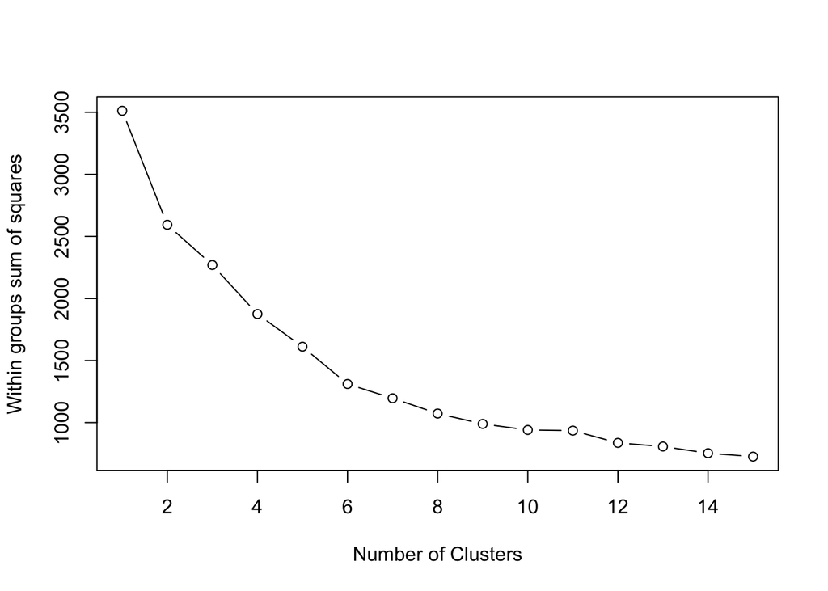

```r
wss <- (nrow(MyData)-1)*sum(apply(MyData,2,var))
for (i in 2:15) wss[i] <- sum(kmeans(MyData,
   centers=i)$withinss)
plot(1:15, wss, type="b", xlab="Number of Clusters",
  ylab="Within groups sum of squares")
```

##### This graph is not necessarily very helpful when it comes to determining the optimal cluster numbers. It appears, that 3, 5 or 6 may appear the elbow points where the graph turns. This method may be easy, however, it will be on the observer to make a determination. In other words, it is not exact, but very helpful.

### The Gap Statistics

##### This compares the “total within intra-cluster variation for different values of K with their expected values under null reference distribution of data. Therefore, the otpimal cluster will be the value that maximize the gap statistics.”<sup>1</sup> This appraoch is more accurate compared to the Elbow Method.

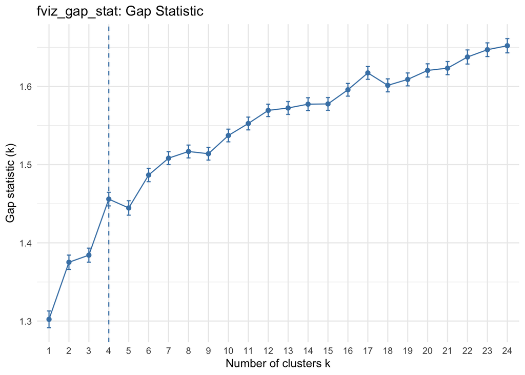

```r
gap_stat <- clusGap(MyData, FUN = kmeans, nstart = 30, K.max = 24, B = 50)
fviz_gap_stat(gap_stat) + theme_minimal() + ggtitle("fviz_gap_stat: Gap Statistic")
```

### The Silhouette Plot

##### This plot computes the average silhouette of observations for different K values. The optimal K value will be the one that maximizes the average silhouette value.

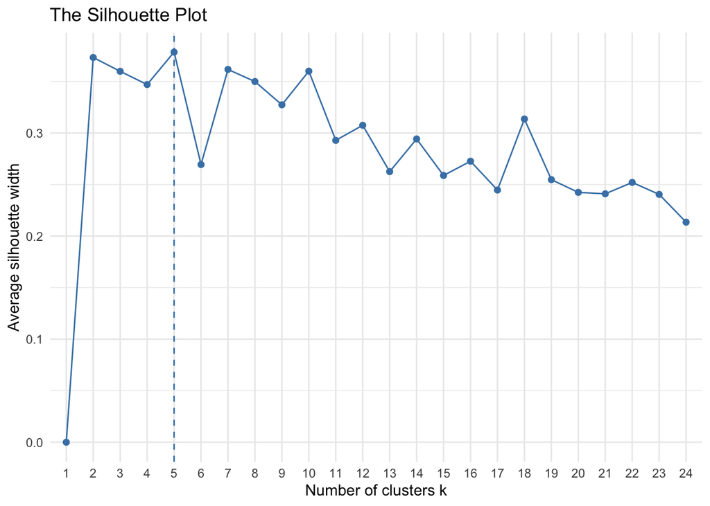

```r
fviz_nbclust(MyData, kmeans, method = "silhouette", k.max = 24) + theme_minimal() + ggtitle("The Silhouette Plot")
```

##### In the above case, the optimal K value is `K = 5`. So, we have a few contenders here from these three different methods of determining the optimal K value.

## Clustering the Given Dataset

##### Now, we will cluster the dataset in the several optimal K values we have acquired.

```r
fit1 <- kmeans(MyData, centers = 2) # 2 cluster solution
fit2 <- kmeans(MyData, centers = 3) # 3 cluster solution
fit3 <- kmeans(MyData, centers = 5) # 5 cluster solution
fit4 <- kmeans(MyData, centers = 6) # 6 cluster solution
```

## Plotting Clusters

[figure not shown]

```r
Cluster1 <- fviz_cluster(fit1, geom = "point", data = MyData) + ggtitle("A 2 Cluster Solution")
Cluster2 <- fviz_cluster(fit2, geom = "point", data = MyData) + ggtitle("A 3 Cluster Solution")
Cluster3 <- fviz_cluster(fit3, geom = "point", data = MyData) + ggtitle("A 5 Cluster Solution")
Cluster4 <- fviz_cluster(fit3, geom = "point", data = MyData) + ggtitle("A 6 Cluster Solution")

grid.arrange(Cluster1, Cluster2, Cluster3, Cluster4, nrow = 2)
```

## Difficult Clusters

```r
Cluster2 <- fviz_cluster(fit2, geom = "point", data = MyData) + ggtitle("A 3 Cluster Solution")
```

# Conclusion

##### During this assingment, we have used a k-means clustering method to classify data. As we are dealing with distances, it is important to make sure that the data is numberic. Scaling the data also helps to evaluate k distances and sum of squares. Furthermore, making sure we get rid of NA or NULL values from the dataset is important as we are dealing with distances. It is also important to find the optimal k values. Depending on the K values, we may have completely different classification of data observations. Therefore, finding a working optimal k value is very key.

# References

1. https://towardsdatascience.com/10-tips-for-choosing-the-optimal-number-of-clusters-277e93d72d92  
   https://uc-r.github.io/kmeans_clustering  
   https://www.r-bloggers.com/10-tips-for-choosing-the-optimal-number-of-clusters/